# Datenvisualisierung mit R

Funktionen II

Armin Schäfer

schaefer@politik.uni-mainz.de

26.06.2025

## Kursmaterialien

Alle Unterlagen einschließlich des Codes, mit dem die Folien erzeugt worden sind, finden Sie auf folgender Seite: https://github.com/ArminSchaefer/DataVis

## Hinweis zum Einstieg

**Tipp**

Falls Sie ein neues Skript erstellen, ist es sinnvoll, alle Funktionen *an den Anfang* zu stellen. Generell gilt: Wenn Sie den Cursor auf die Funktion richten und F2 drücken, landen Sie automatisch dort, wo sie definiert wurde.

## Bestehende Funktionen anwenden

Vordefinierte Funktionen – die wir nicht ausdrücklich mit `name <- function...` definieren – nennt man anonyme oder Lambda-Funktionen. Um sie in `mutate(across...)` nutzen zu können, verwenden wir folgende Syntax:<sup>1</sup>

```r
ces_agg <- ces %>%
  summarise(across(ends_with("_rs"), ~mean(x, na.rm = TRUE))) # neue Syntax
```

[^1]: Was ich vor zwei Wochen gezeigt hatte, funktioniert auch, ist aber nicht mehr der neueste Stand.

## Zahlen in Missings umwandeln

```r
missings <- c(997, 998, 999)

fix_na <- function(x) {
  if_else(x %in% missings, NA, x)
}
# da wir nicht die Zahlen selbst nennen, ist die Funktion flexibler einsetzbar!

ces <- ces %>%
  mutate(across(CC22_330a:CC22_330c, fix_na))
```

[^2]: In diesem Fall habe ich diese Werte zu Übungszwecken erzeugt.

## Variablenlevel umbenennen

In der Übungsaufgabe haben Sie die Variablen CC22_340a und CC22_340g verwendet. Diese Variablen haben acht Ausprägungen und NAs. Das Ziel ist nun, eine Funktion zu erstellen, die die Zahlen der Zellen in die in der Tabelle genannten Label umwandelt und den Wert “8” (not sure) zu einem fehlenden Wert erklärt. D.h., wir benötigen eine Funktion mit `case_when()`.

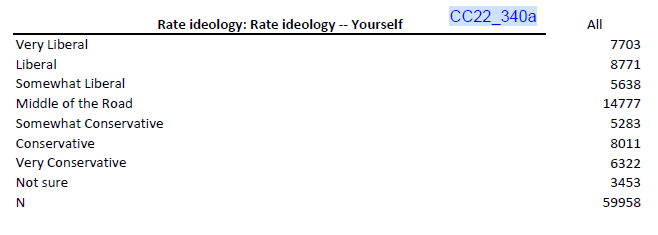

## Variablenlevel umbenennen

```r
fct_rename <- function(x) {
  x = case_when(
    x == 1 ~ "very liberal",
    x == 2 ~ "liberal",
    x == 3 ~ "somewhat liberal",
    x == 4 ~ "middle of the road",
    x == 5 ~ "somewhat conservative",
    x == 6 ~ "conservative",
    x == 7 ~ "very conservative"
  )
}

tmp <- ces %>% # nicht unseren Datensatz verändern!
  mutate(across(c(CC22_340a, CC22_340g), fct_rename, # ohne ~
                .names = "{.col}_fac"))  # neue Spalten mit der Endung "_fac"
```

Was müssen Sie ändern, um diese Umkodierung auf **alle acht Variablen** anzuwenden, die dieselbe Art von Einschätzungen abfragen (sie beginnen alle mit “CC22_340”)?

## Umbenennen, dann ordnen

Label mit der erstellten Funktion `fct_rename` vergeben.

```r
ces <- ces %>%
  mutate(across(starts_with("CC22_340"), fct_rename,
                .names = "{.col}_fac"))
```

Jetzt mit der anonymen Funktion `fct_relevel()` ordnen.

## Umbenennen, dann ordnen

```r
ordered_levels <- c("very liberal", "liberal", "somewhat liberal",
                   "middle of the road", "somewhat conservative",
                   "conservative", "very conservative")

ces <- ces %>%
  mutate(across(ends_with("_fac"), ~fct_relevel(., ordered_levels)))
```

Der `.` in `~fct_relevel(.)` ist notwendig, damit die Funktion auf alle Spalten angewendet wird, die vorab ausgewählt wurden.

# Ganze Grafiken in einer Funktion erzeugen

## Unsere Grafik (in nicht perfekter Darstellung)

```r
ces %>%
  filter(!is.na(CC22_340a_fac), !is.na(CC22_340g_fac)) %>%
  ggplot(aes(x = CC22_340a_fac, fill = CC22_340g_fac)) +
  geom_bar(position = "fill") +
  scale_fill_viridis_d(direction = -1) +
  labs(x = "Ideological self-placement",
       y = "Perceived position Supreme Court", fill = NULL)+
  coord_flip()+ # vertauscht x- und y-Achse.
  theme(legend.position = "top")
```

## Eine ggplot-Funktion

Wir kopieren den Code und ersetzen als erstes den Datensatz durch data.

```r
our_ggplot <- function(data){

  data %>%
  filter(!is.na( CC22_340a_fac ), !is.na( CC22_340g_fac )) %>%
  ggplot(aes(x = CC22_340a_fac, fill = CC22_340g_fac )) +
  geom_bar(position = "fill") +
  scale_fill_viridis_d(direction = -1) +
  labs(x = "Ideological self-placement",
       fill = NULL,
       y = "Perceived position Supreme Court")+
  coord_flip()+
  theme(legend.position = "top")
}

our_ggplot(ces)
```

## Eine ggplot-Funktion

Nun ersetzen wir nicht nur den Datensatz durch data, sondern auch die Variablen durch die Platzhalter (var1 und var2).

```r
our_ggplot <- function(data, var1, var2){

  data %>%
  filter(!is.na( var1 ), !is.na( var2 )) %>%  # ersetzt
  ggplot(aes(x = var1, fill = var2 )) +       # ersetzt
  geom_bar(position = "fill") +
  scale_fill_viridis_d(direction = -1) +
  labs(x = "Ideological self-placement",
       fill = NULL,
       y = "Perceived position Supreme Court")+
  coord_flip()+
  theme(legend.position = "top")
}

our_ggplot(ces, CC22_340a_fac, CC22_340g_fac)
```

Funktioniert nicht…

## Der “Tunnel” {{ }}

In einer Funktion durchsucht `R` den Datensatz nach Spalten, die den genannten Namen (z.B. “var1”) haben. Aber eine Spalte mit diesem Namen gibt es im Datensatz ces nicht – deshalb bekommen wir eine Fehlermeldung.

Wir müssen R mitteilen, dass es sich bei “var1” und “var2” um **Platzhalter** handelt, die selbst **keine Variablennamen sind**. Dies geschieht mit einer doppelten geschweiften Klammer: {{ }}.<sup>1</sup>

[^3]: Bildlich können Sie sich das wie den Eingang zu einem Tunnel vorstellen, an dessen Ende die Variablen stehen, die wir verwenden möchten.

## Eine Funktion mit {{ }}

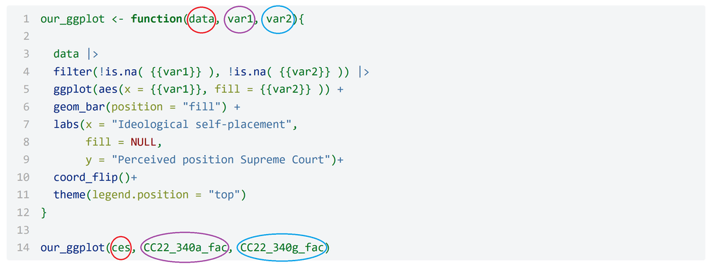

Setzen Sie in diese Funktion die Variable CC22_340d_fac ein. Ändert sich die Darstellung?

## Die Beschriftung anpassen (…)

```r
our_ggplot <- function(data, var1, var2, ...){

  data %>%
  filter(!is.na( {{var1}} ), !is.na( {{var2}} )) %>%
  ggplot(aes(x = {{var1}}, fill = {{var2}} )) +
  geom_bar(position = "fill") +
  scale_fill_viridis_d(direction = -1) +
  labs(x = "Ideological self-placement",
       fill = NULL, ...)+
  coord_flip()+
  theme_light()+
  theme(legend.position = "top")
}

our_ggplot(ces, CC22_340a_fac, CC22_340d_fac, y = "Perceived position Trump")

our_ggplot(ces, CC22_340a_fac, CC22_340c_fac, y = "Perceived position Biden")
```

## Grafiken kombinieren

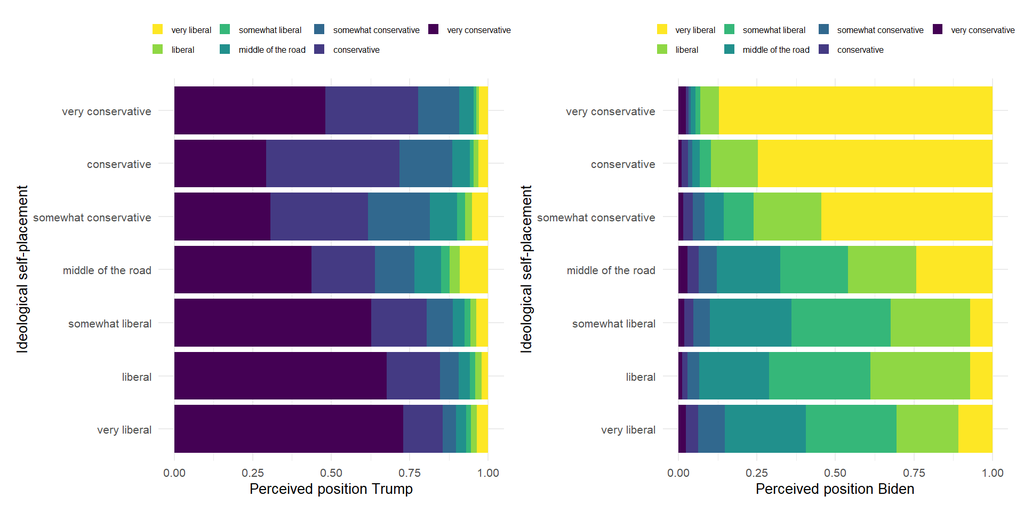

```r
library(patchwork) # oben ins Skript bei p_load einfügen!

p1 <- our_ggplot(ces, CC22_340a_fac, CC22_340d_fac, y = "Perceived position Trump")
p2 <- our_ggplot(ces, CC22_340a_fac, CC22_340c_fac, y = "Perceived position Biden")

p1 + p2
```

## Grafiken kombinieren

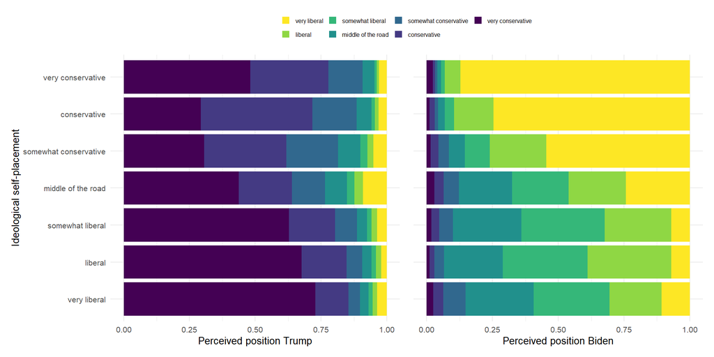

```r
p2 <- p2 +
  theme(axis.title.y = element_blank(),
        axis.text.y = element_blank(),
        axis.ticks.y = element_blank())

p1 + p2+
  plot_layout(guides = "collect") & theme(legend.position = 'top')
```

## Bildung und Wahlverhalten – zweites Beispiel

Wir wollen nun den Zusammenhang von Bildungsabschlüssen und Wahlverhalten untersuchen. Dazu müssen erst den Datensatz vorbereiten.

```r
ces <- ces %>%
  mutate(biden = ifelse(presvote20 == "Biden", 1, 0),
         trump = ifelse(presvote20 == "Trump", 1, 0),
         other = ifelse(presvote20 == "other", 1, 0),
         edu = fct_relevel(edu, "high school", "some college",
                           "2-year college", "4-year college",
                           "post-grad"))
```

## Bildung und Wahlverhalten – zweites Beispiel

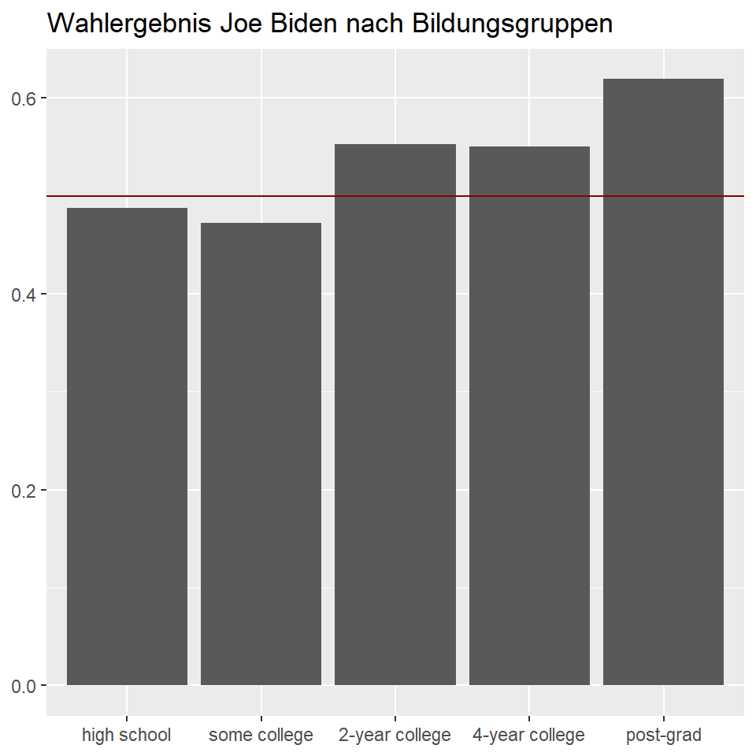

```r
ces %>%
  filter(!is.na(edu)) %>%
  group_by(edu) %>%
  summarise(perc = mean(biden, na.rm=TRUE)) %>%
  ggplot(aes(x = edu, y = perc))+
  geom_col()+
  geom_hline(yintercept = 0.5, color = "darkred")+
  labs(x = NULL, y = NULL,
       title = "Wahlergebnis Joe Biden nach Bildungsgruppen")
```

Erstellen Sie nun eine Funktion, damit Sie auch die Werte für Trump darstellen können.

## Als Funktion

```r
fct_barplot <- function(var1, ...){
  ces %>%
  filter(!is.na(edu)) %>%
  group_by(edu) %>%
  summarise(perc = mean( {{var1}}, na.rm=TRUE)) %>%
  ggplot(aes(x = fct_relevel(edu, "high school", "some college",
                             "2-year college", "4-year college", "post-grad"),
             y = perc))+
  geom_col()+
  geom_hline(yintercept = 0.5, color = "darkred")+
  labs(x = NULL, y = NULL, ...)
}
```

## Ergebnis

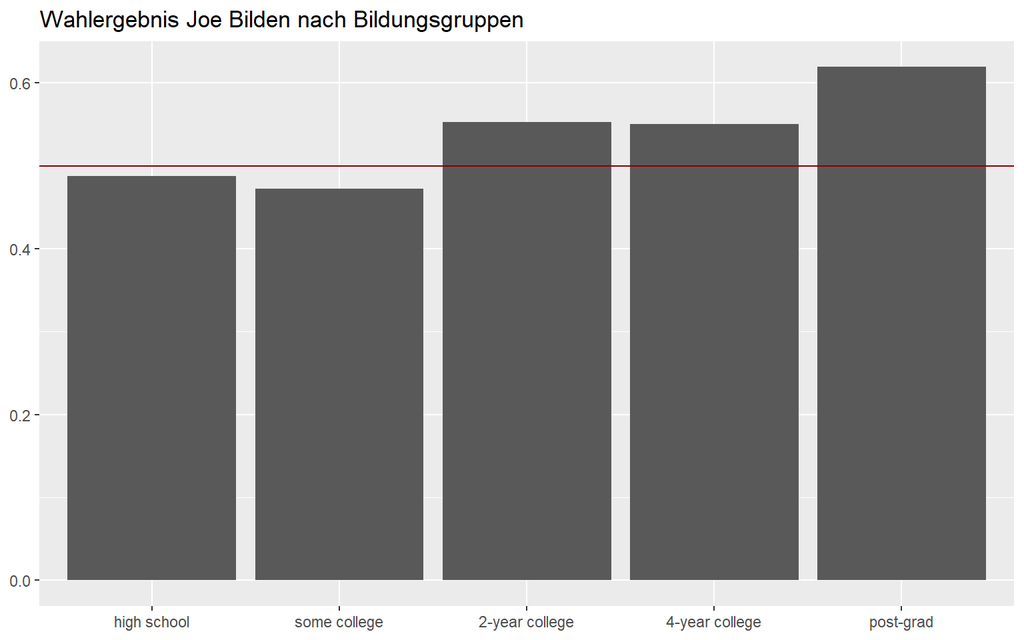

```r
fct_barplot(biden, title = "Wahlergebnis Joe Bilden nach Bildungsgruppen")
```

## Weitere `ggplot()`-Elemente hinzufügen

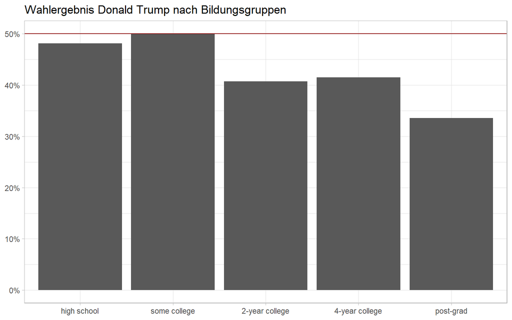

```r
fct_barplot(trump, title = "Wahlergebnis Donald Trump nach Bildungsgruppen")+
  scale_y_continuous(labels = scales::percent)+
  theme_light()
```

## Weitere `ggplot()`-Elemente hinzufügen

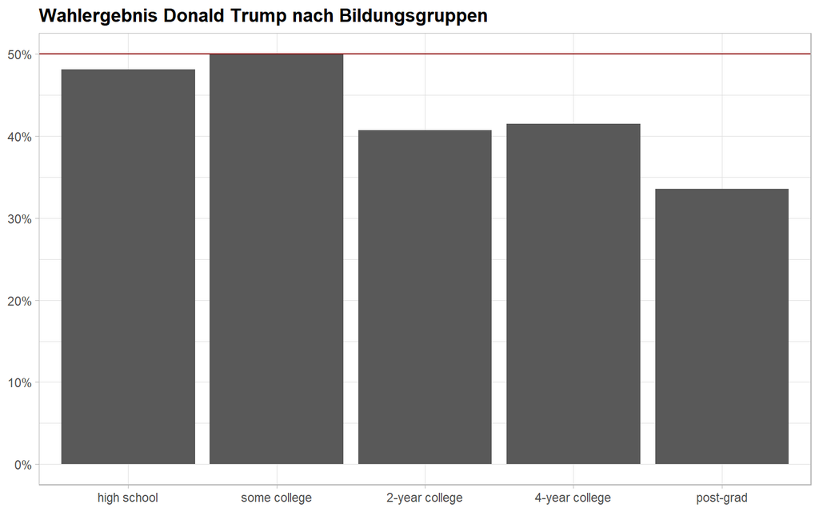

```r
fct_barplot(trump, title = "Wahlergebnis Donald Trump nach Bildungsgruppen")+
  scale_y_continuous(labels = scales::percent)+
  theme_light()+
  theme(plot.title = element_text(face = "bold"))
```

## Evaluation

[figure not shown]

Losung: 472TN